# Reign Soccer Survey Data

Jordan Gropper

8/27/2021

# Data overview

- Survey description: 684 respondents, answering over 200 questions having to do with their feelings and opinions on Seattle Reign and the matches.
  - The responses were collected on sliding scales, like from -3 to 3 on satisfaction or from 1 - 7 on their loyalty to the team
  - I am basing my findings on these 684 respondents, this a reasonable sample size but does not account for all fans.
- What I am looking to do with this data
  - I found Two Key Changes to potentially impact satisfaction, Interest and Viewership of our fans.
  - They revolve around the coach being so special to the fans and the popularity of TV & Twitter viewership
  - With these changes I hope not only Interest and Viewership will increase, but Attendance and Purchasing.

[figure not shown]

# Quick Facts

- Respondents
  - The respondents were mainly white women between the age of 30 - 50 and more than half of our respondents made over $80,000
  - Our Respondents alone checked our media sites over 4,000 times a week last season
  - Satisfaction and Interest in the team is very high in respondents, but I have some recommendations to potentially increase that.
  - I did notice the significant drop in first time attendance in 2016, and only 30% intend to get season tickets for 2017
  - This could be due to a multitude of reasons I will dive into here, as well as in our memo and dashboard.
  - The most preferred game time is Wednesday Evening, Over 500 respondents want Wednesday Evening Matches.

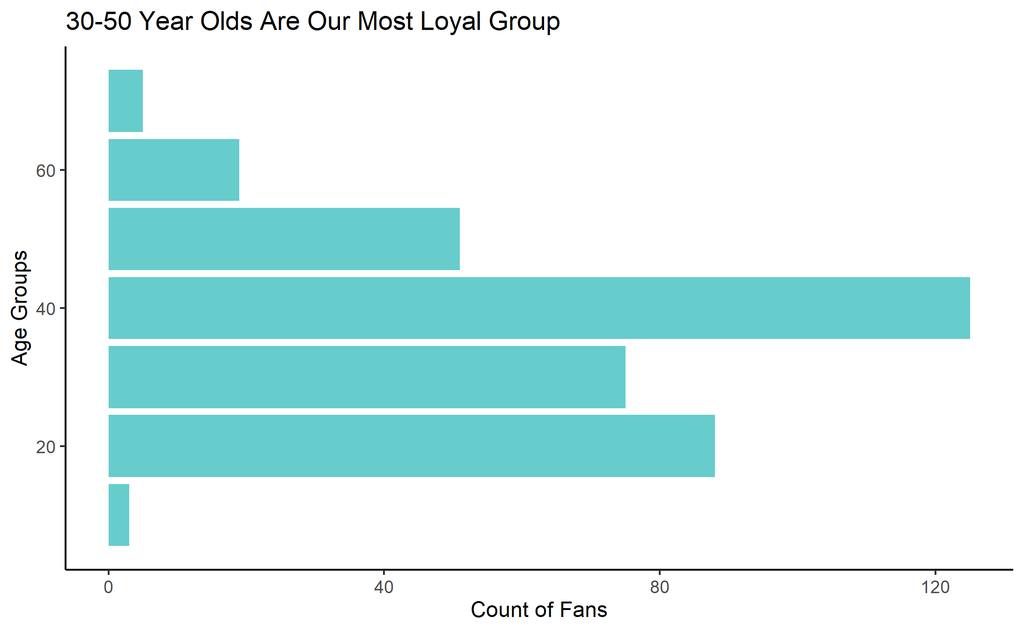

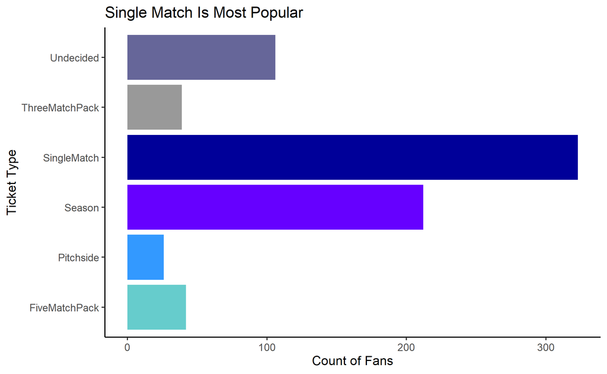